# Dataviz: Datos de Miercoles

DataViz

R

Data

En este contiene las visualizaciones que realice para Datos de Miercoles.

[figure not shown]

# ¿Que es datos de Miercoles?

Datos de miércoles es el primo latinoamericano de #tidytuesday, un proyecto semanal de datos organizado por la comunidad de R, que busca que sus participantes desarrollen sus habilidades procesando datos para crear gráficos significativos usando ggplot2, tidyr, dplyr y otras herramientas del tidyverse. El proyecto original surgió en el marco de la comunidad de aprendizaje online R4DS y desde abril de 2019 la comunidad sudamericana de R impulsa una versión local en español. [^1]

# DATAVIZ 📊

**R** es uno de los lenguajes más populares para el desarrollo de visualizaciones y su paquete más popular en los ultimos años es **GGPLOT**. Para poder aprender a desarrollar visualizaciones comence a practicar en base a los desafios que se publicaban semana a semana en **`Datos de Miércoles`**.

Si quieres dar tus primeros pasos para el desarrollo de visualizaciones en R, te dejo este [post](https://r0mymendez.github.io/romymendezblog/posts/2021-02-21-introduccin-a-visualizaciones-con-r/) que realice con un curso gratis de 3 horas ⌛.

Algunas de las visualizaciones que realice para esta comunidad son las siguientes 🎉.

## [Rankings Musicales - SPOTIFY](https://github.com/r0mymendez/R/tree/master/DatosDeMiercoles/20190515)

[figure not shown]

## [Capitulos de RLadies](https://github.com/r0mymendez/R/tree/master/DatosDeMiercoles/20190625)

[figure not shown]

## [Pokemon](https://github.com/r0mymendez/R/tree/master/DatosDeMiercoles/20190713)

[figure not shown]

## [Datos de la OMS sobre tuberculosis](https://github.com/r0mymendez/R/tree/master/DatosDeMiercoles/20190521)

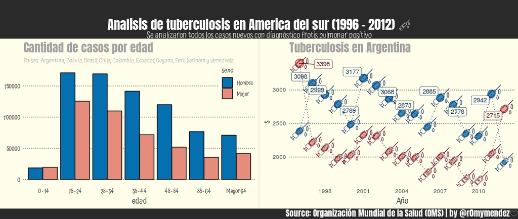

## [Reseñas de Vinos](https://github.com/r0mymendez/R/blob/master/DatosDeMiercoles/20190612)

Datos sobre reseñas de vinos publicadas en la revista WineEnthusiast 🍷🍷🍷

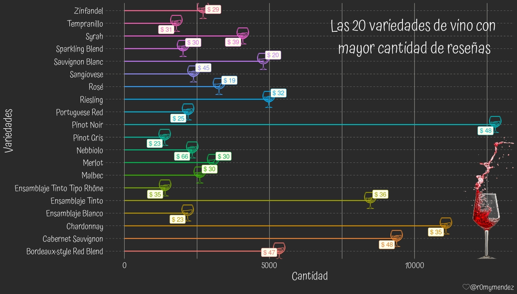

Los datos de los quesos fueron tomados de los siguientes sitios: * 🍷 [Club bonvivir](https://www.bonvivir.com/2013/01/17/quesos-vinos/) * 🍷 [Vix](https://www.vix.com/es/imj/gourmet/2008/03/26/guia-de-vinos-y-quesos) * 🍷 [Vinepair](https://vinepair.com/wine-blog/an-illustrated-guide-to-pairing-wine-and-cheese/)

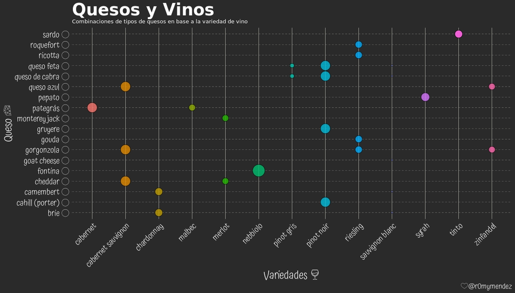

## [Gapminder](https://github.com/r0mymendez/R/blob/master/DatosDeMiercoles/20190410/)

[figure not shown]

## [Comercio Hispanoamérica-Mundo](https://github.com/r0mymendez/R/tree/master/DatosDeMiercoles/20190502/)

Analisis de exportaciones Argentina del año 2017.

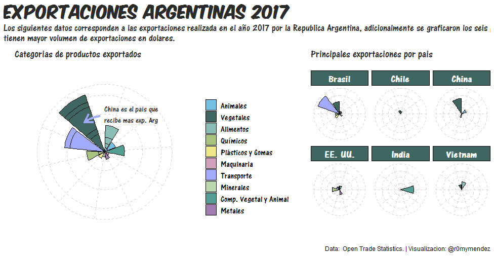

## [Datos sobre el Índice de Libertad](https://github.com/r0mymendez/R/tree/master/DatosDeMiercoles/20190819)

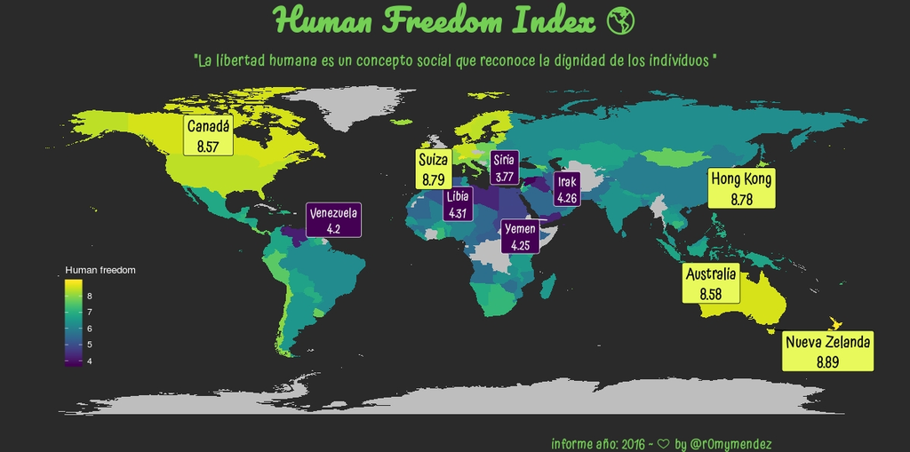

## [IMDB- Ranking de películas](https://github.com/r0mymendez/R/tree/master/DatosDeMiercoles/20200221)

[figure not shown]

## [30 días de gráficos](https://github.com/r0mymendez/R/tree/master/DatosDeMiercoles/20200608)

Para esta entrega realice un gif con las cantidad de TvShow por año que se encuentran en las plataformas Disney, Hulu, Prime Video y Netflix Data Source: https://www.kaggle.com/ruchi798/tv-shows-on-netflix-prime-video-hulu-and-disney

[figure not shown]

[^1]: [GitHub Datos de miercoles](https://github.com/cienciadedatos/datos-de-miercoles)